# `glmulti` usage introduction

```r
library(CodeClanData)
library(tidyverse)
```

```r
glimpse(insurance)
```

```
## Observations: 1,338
## Variables: 7
## $ age      <dbl> 19, 18, 28, 33, 32, 31, 46, 37, 37, 60, 25, 62, 23, 56,…
## $ sex      <chr> "female", "male", "male", "male", "male", "female", "fe…
## $ bmi      <dbl> 27.900, 33.770, 33.000, 22.705, 28.880, 25.740, 33.440,…
## $ children <dbl> 0, 1, 3, 0, 0, 0, 1, 3, 2, 0, 0, 0, 0, 0, 0, 1, 1, 0, 0…
## $ smoker   <chr> "yes", "no", "no", "no", "no", "no", "no", "no", "no", …
## $ region   <chr> "southwest", "southeast", "southeast", "northwest", "no…
## $ charges  <dbl> 16884.924, 1725.552, 4449.462, 21984.471, 3866.855, 375…
```

Let’s use `caret` to perform train-test splitting. The `createDataPartition()` function has the nice feature that it takes in a `y=` argument specifying outcomes, and it will try to ensure similar distributions of those outcomes in train and test sets.

```r
library(glmulti)
library(caret)
```

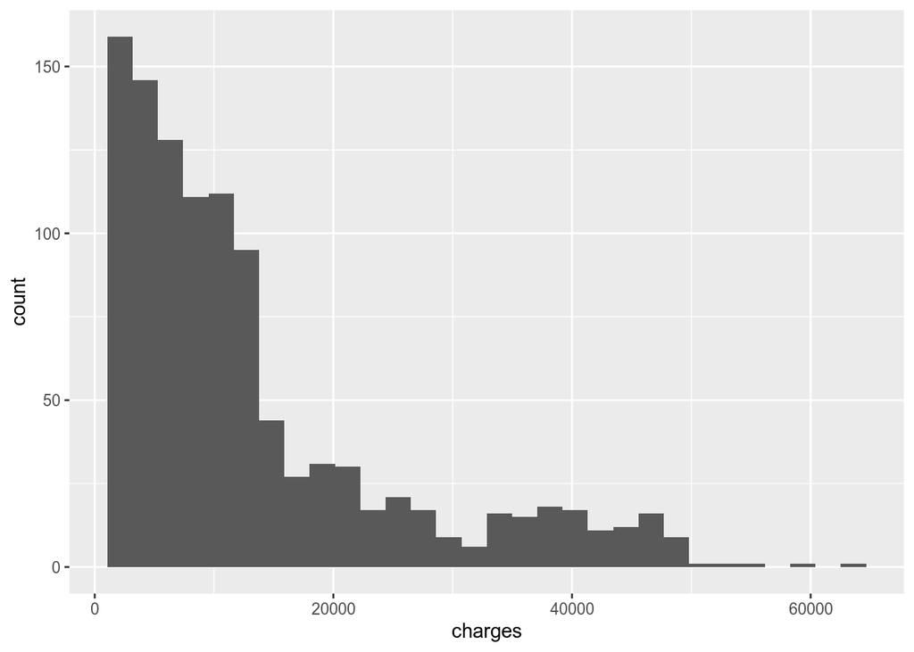

```r
train_index <- createDataPartition(insurance$charges, p = 0.8, list = FALSE, times = 1)

train <- insurance[train_index, ]
test <- insurance[-train_index,]

train %>%
  ggplot(aes(x = charges)) +
  geom_histogram()
```

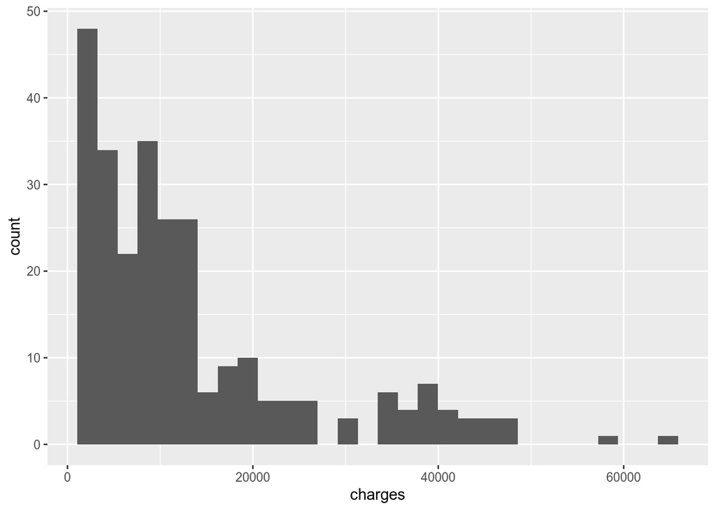

```r
test %>%
  ggplot(aes(x = charges)) +
  geom_histogram()
```

Now we’ll use `glmulti()` for predictor selection. First, let’s get the size of the full problem

```r
glmulti_fit <- glmulti(
  charges ~ ., # model to fit, in this case, charges varies with everything
  level = 2, # level = 2 means try pairwise interactions. level = 1 means main effects only
  data = train, # data to use for fitting
  minsize = 0, # min size of model to try, in number of predictors
  maxsize = -1, # max size to try, set to -1 for unlimited
  marginality = TRUE, # marginality true means include pairwise interaction only if both main effects present in model.
  method = "d", # method "d" means trial run, to get size of problem. Set to "h" for exhaustive search, or "g" for genetic algorithm
  confsetsize = 1000, # how many models should glmulti() return? Must be less than total size of problem
  plotty = FALSE, # provide progress plots? Generally annoying.
  report = TRUE, # provide progress reports? Generally useful.
  fitfunction = lm, # use lm() as fit function. Can also use glm() for logistic regression.
  crit = aic # criterion for selecting best models.
)
```

```
## Initialization...
## TASK: Diagnostic of candidate set.
## Sample size: 1072
## 0 factor(s).
## 6 covariate(s).
## 0 f exclusion(s).
## 0 c exclusion(s).
## 0 f:f exclusion(s).
## 0 c:c exclusion(s).
## 0 f:c exclusion(s).
## Size constraints: min =  0 max = -1
## Complexity constraints: min =  0 max = -1
## Marginality rule.
## Your candidate set contains 40069 models.
```

Hmm, 40069 possible models in full search space. The genetic algorithm and exhaustive search would both be able to hand this in around 5 minutes, but let’s limit the model space just by way of example.

```r
glmulti_fit <- glmulti(
  charges ~ ., # model to fit, in this case, charges varies with everything
  level = 2, # level = 2 means try pairwise interactions. level = 1 means main effects only
  data = train, # data to use for fitting
  minsize = 0, # min size of model to try, in number of predictors
  maxsize = 10, # max size to try, set to -1 for unlimited
  marginality = TRUE, # marginality true means include pairwise interaction only if both main effects present in model.
  method = "d", # method "d" means trial run, to get size of problem. Set to "h" for exhaustive search, or "g" for genetic algorithm
  confsetsize = 1000, # how many models should glmulti() return? Must be less than total size of problem
  plotty = FALSE, # provide progress plots? Generally annoying.
  report = TRUE, # provide progress reports? Generally useful.
  fitfunction = lm, # use lm() as fit function. Can also use glm() for logistic regression.
  crit = aic # criterion for selecting best models.
)
```

```
## Initialization...
## TASK: Diagnostic of candidate set.
## Sample size: 1072
## 0 factor(s).
## 6 covariate(s).
## 0 f exclusion(s).
## 0 c exclusion(s).
## 0 f:f exclusion(s).
## 0 c:c exclusion(s).
## 0 f:c exclusion(s).
## Size constraints: min =  0 max = 10
## Complexity constraints: min =  0 max = -1
## Marginality rule.
## Your candidate set contains 6926 models.
```

Now the model space is down to 6926 models. Let’s go ahead and use exhaustive search on this, with `aic()` as our criterion function.

```r
glmulti_fit <- glmulti(
  charges ~ .,
  level = 2,
  data = train,
  minsize = 0,
  maxsize = 10,
  marginality = TRUE,
  method = "h",
  confsetsize = 1000,
  plotty = FALSE,
  report = TRUE,
  fitfunction = lm,
  crit = aic
)
```

```
## Initialization...
## TASK: Exhaustive screening of candidate set.
## Fitting...
##
## After 50 models:
## Best model: charges~1+age+sex+bmi+bmi:sex
## Crit= 23052.4076524462
## Mean crit= 23101.578525738
##
## After 100 models:
## Best model: charges~1+age+sex+bmi+children+bmi:sex
## Crit= 23050.8437539365
## Mean crit= 23078.8197463487
##
## After 150 models:
## Best model: charges~1+age+bmi+smoker+smoker:bmi
## Crit= 21289.2039322556
## Mean crit= 22796.0060227788
##
## After 200 models:
## Best model: charges~1+age+bmi+smoker+smoker:bmi
## Crit= 21289.2039322556
## Mean crit= 22474.1874713906
##
## After 250 models:
## Best model: charges~1+age+bmi+smoker+smoker:bmi
## Crit= 21289.2039322556
## Mean crit= 22340.3448478786
##
## After 300 models:
## Best model: charges~1+age+bmi+smoker+smoker:bmi
## Crit= 21289.2039322556
## Mean crit= 22256.3190384189
##
## After 350 models:
## Best model: charges~1+age+bmi+children+smoker+smoker:bmi
## Crit= 21271.859471047
## Mean crit= 22157.5760296657
##
## After 400 models:
```

[output cut: 664 more lines]

```
## After 7050 models:
## Best model: charges~1+age+bmi+children+smoker+region+smoker:bmi+region:age+region:bmi
## Crit= 21260.0258060386
## Mean crit= 21270.6074625497
##
## After 7100 models:
## Best model: charges~1+age+bmi+children+smoker+region+smoker:bmi+region:age+region:bmi
## Crit= 21260.0258060386
## Mean crit= 21270.5257096241
##
## After 7150 models:
## Best model: charges~1+age+bmi+children+smoker+region+smoker:bmi+region:age+region:bmi
## Crit= 21260.0258060386
## Mean crit= 21270.4813261541
## Completed.
```

The `glmulti_fit` object we saved above has a bunch of useful stuff stored in slots. In particular, slot `@objects` contains all 1000 models we asked `glmulti()` to keep above (via the `confsetsize` argument). Let’s use each of these saved model objects (remember they have been trained on the `train` set) to predict `charges` for the `test` set. We’ll then calculate RMSE for each model on the test set

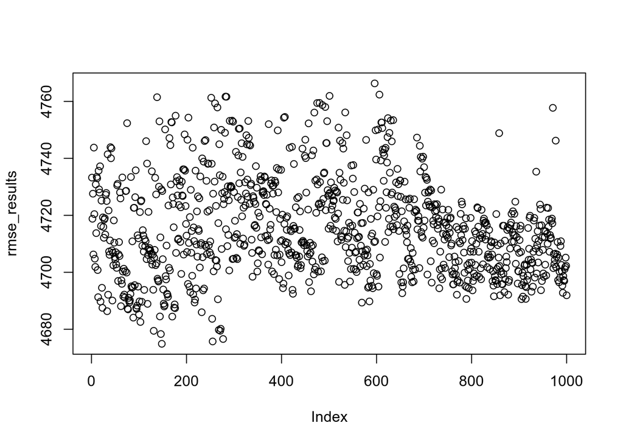

```r
rmse_results <- numeric(1000)
for (i in 1:1000){
  this_model <- glmulti_fit@objects[[i]]
  predictions <- predict(this_model, newdata = test)
  rmse_results[i] <- sqrt(mean((predictions - test$charges)^2))
}
plot(rmse_results)
```

Lots of reasonably competitve models!

The 1000 models we requested are stored in the `glmulti_fit` in order of the criterion function, lowest first (you can see these values in the `@crits` slot).

Let’s see what the 600th model looks like:

```r
glmulti_fit@objects[[600]]
```

```
##
## Call:
## fitfunc(formula = as.formula(x), data = data)
##
## Coefficients:
##               (Intercept)                        age
##                   257.391                    198.960
##                   sexmale                        bmi
##                  -385.259                    -56.638
##                  children                  smokeryes
##                   498.117                 -20908.552
##           regionnorthwest            regionsoutheast
##                  -598.340                  -1037.741
##           regionsouthwest                    age:bmi
##                 -1689.717                      2.079
##              age:children              bmi:smokeryes
##                     1.323                   1446.781
## smokeryes:regionnorthwest  smokeryes:regionsoutheast
##                   373.917                   -434.593
## smokeryes:regionsouthwest
##                  1115.679
```

# ‘Fooling’ `glmulti()` into using $r^2$

The `glmulti()` function is set up to minimise an information criterion (aic, bic etc), so what do we do if we want to mimic `leaps` and use $r^2$ to select the best model of a given size?

We can trick `glmulti()` into doing this by passing the *negative of $r^2$* as a criterion function, like so

```r
neg_r2 <- function(model){
  sum_model <- summary(model)
  return( -1 * sum_model$r.squared)
}
```

So now finding the model with highest $r^2$ is equivalent to finding the model with lowest $-r^2$!

Let’s now get `glmulti()` to search exhaustively for the ‘best’ model (i.e. highest $r^2$) out to models with 10 predictors:

```r
# save each glmulti_fit object to a list as we go
best_fits <- list()

# search out to models with 10 predictors
num_pred_max <- 10

for (num_pred in 1:num_pred_max){
  # track progress
  print(paste("num_pred =", num_pred))

  # run the search for models of num_pred size
  glmulti_fit <- glmulti(
    charges ~ .,
    level = 2,
    data = train,
    minsize = num_pred, # only models of num_pred size
    maxsize = num_pred, # only models of num_pred size
    marginality = TRUE,
    method = "h",
    confsetsize = 1, # save only best model from this search
    plotty = FALSE,
    report = FALSE,
    fitfunction = lm,
    crit = neg_r2 # our custom crit function
  )

  best_fits <- append(best_fits, glmulti_fit)
}
```

```
## [1] "num_pred = 1"
## [1] "num_pred = 2"
## [1] "num_pred = 3"
## [1] "num_pred = 4"
## [1] "num_pred = 5"
## [1] "num_pred = 6"
## [1] "num_pred = 7"
## [1] "num_pred = 8"
## [1] "num_pred = 9"
## [1] "num_pred = 10"
```

Now calculate the RMSE for the test set for each of the best models of a given size we found above.

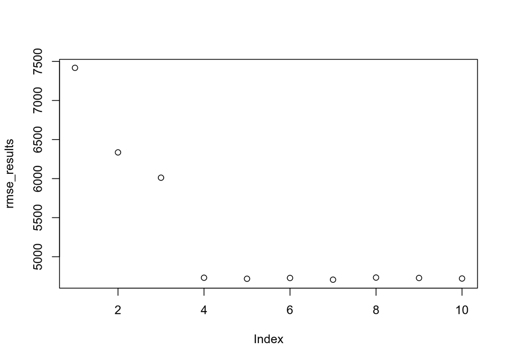

```r
rmse_results <- numeric(num_pred_max)
for (i in 1:num_pred_max){
  this_model <- best_fits[[i]]@objects[[1]]
  predictions <- predict(this_model, newdata = test)
  rmse_results[i] <- sqrt(mean((predictions - test$charges)^2))
}
plot(rmse_results)
```